# IMF Primary Commodity Prices

### Natural Gas, Russian Natural Gas border price in Germany, US$ per Million Metric British Thermal Unit . Type: USD

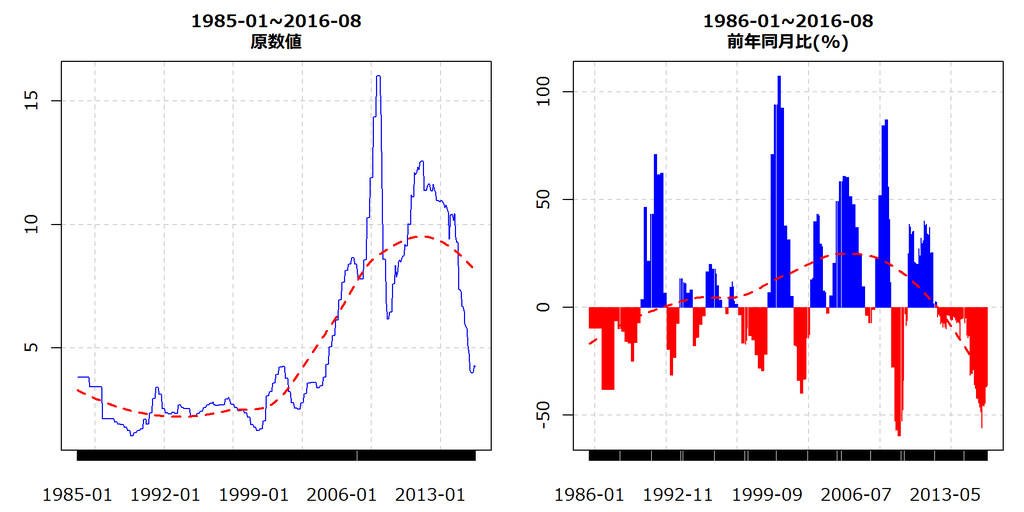

### Natural Gas, Indonesian Liquefied Natural Gas in Japan, US$ per Million Metric British Thermal Unit . Type: USD

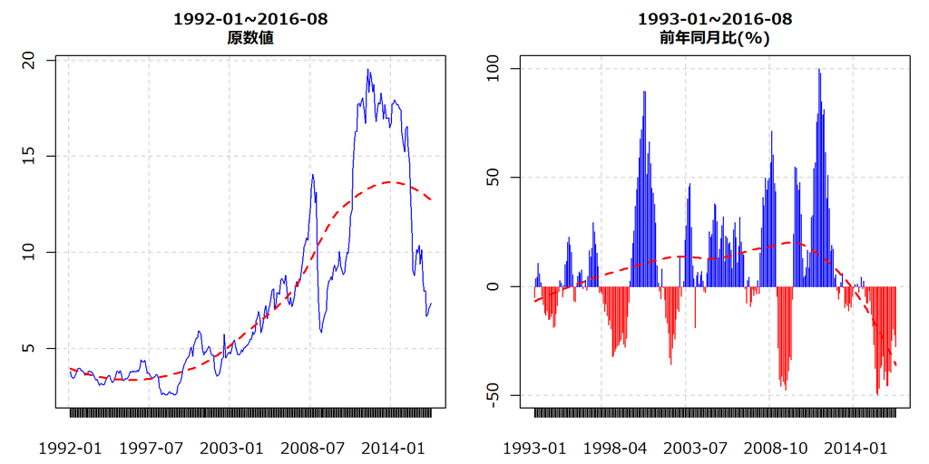

### Natural Gas, Natural Gas spot price at the Henry Hub terminal in Louisiana, US$ per Million Metric British Thermal Unit . Type: USD

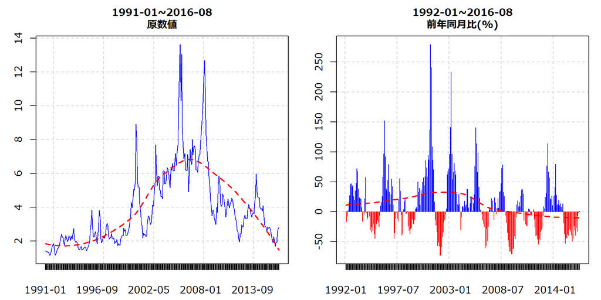

### Nickel, melting grade, LME spot price, CIF European ports, US$ per metric ton . Type: USD

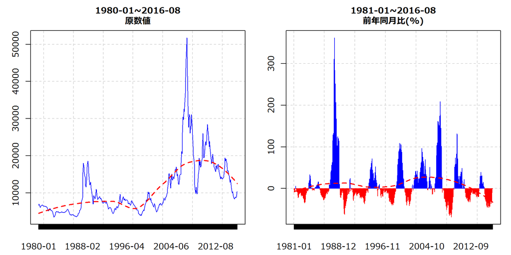

### Crude Oil (petroleum), simple average of three spot prices; Dated Brent, West Texas Intermediate, and the Dubai Fateh . Type: USD

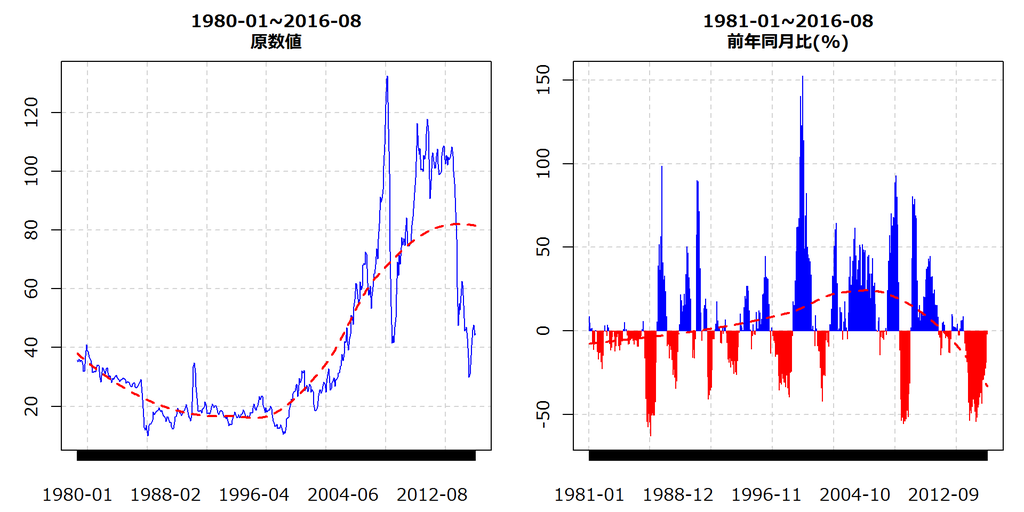

### Crude Oil (petroleum), Dated Brent, light blend 38 API, fob U.K., US$ per barrel . Type: USD

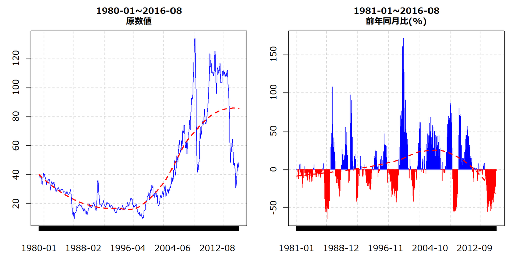

### Oil; Dubai, medium, Fateh 32 API, fob Dubai Crude Oil (petroleum), Dubai Fateh Fateh 32 API, US$ per barrel . Type: USD

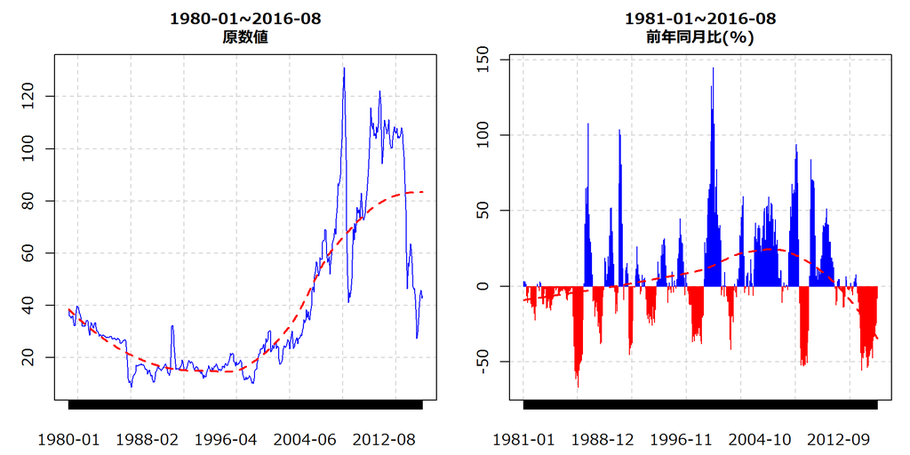

### Crude Oil (petroleum), West Texas Intermediate 40 API, Midland Texas, US$ per barrel . Type: USD

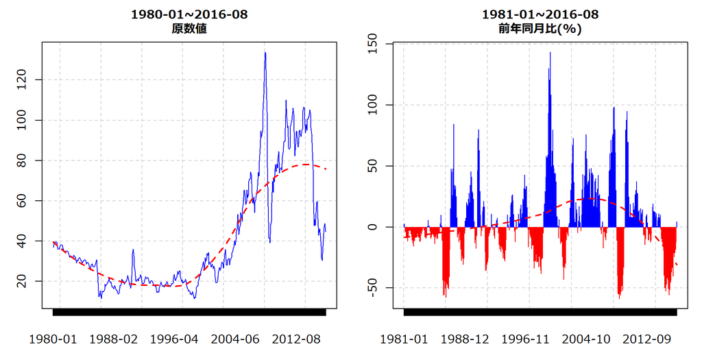

### Olive Oil, extra virgin less than 1% free fatty acid, ex-tanker price U.K., US$ per metric ton . Type: USD

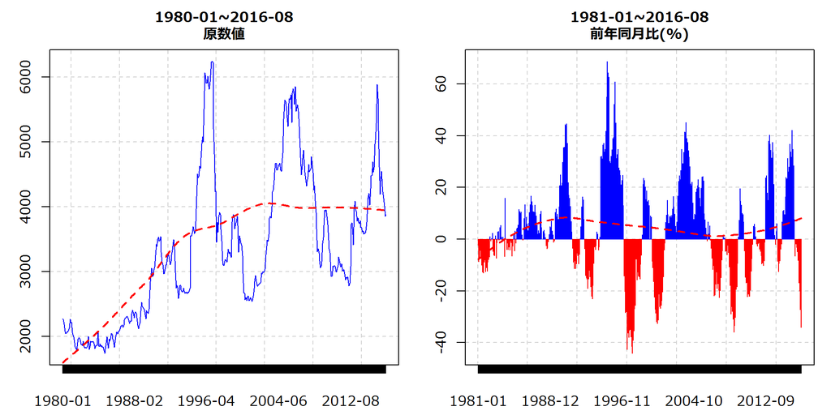

### Oranges, miscellaneous oranges CIF French import price, US$ per metric ton . Type: USD

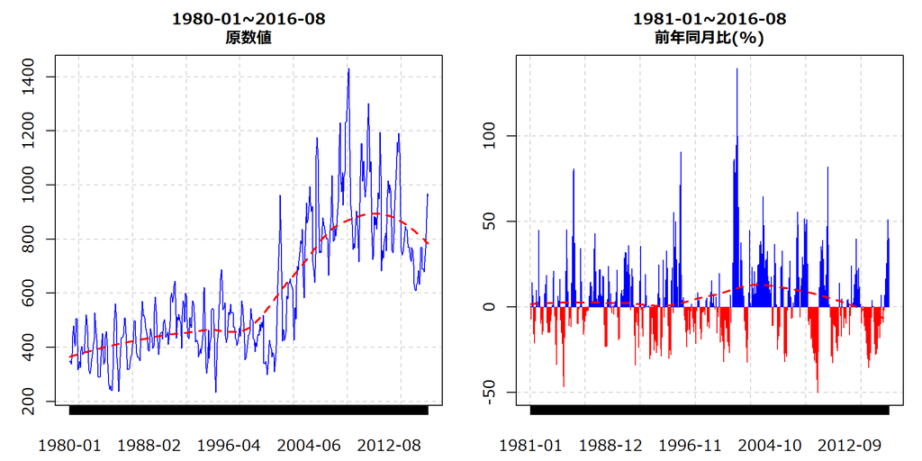

### Palm oil, Malaysia Palm Oil Futures (first contract forward) 4-5 percent FFA, US$ per metric ton . Type: USD

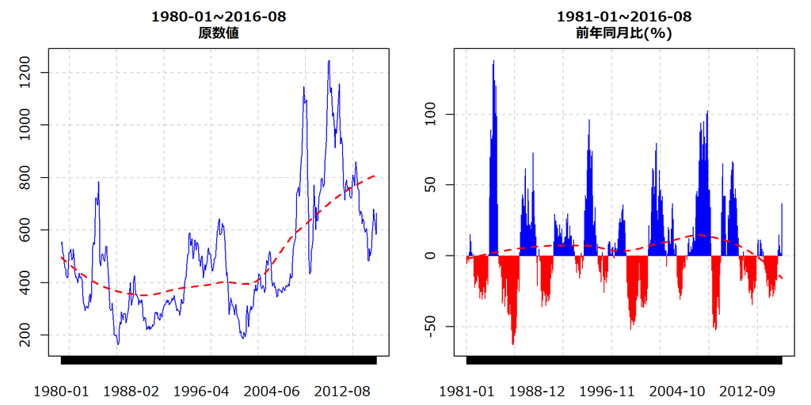

### Swine (pork), 51-52% lean Hogs, U.S. price, US cents per pound. . Type: USD

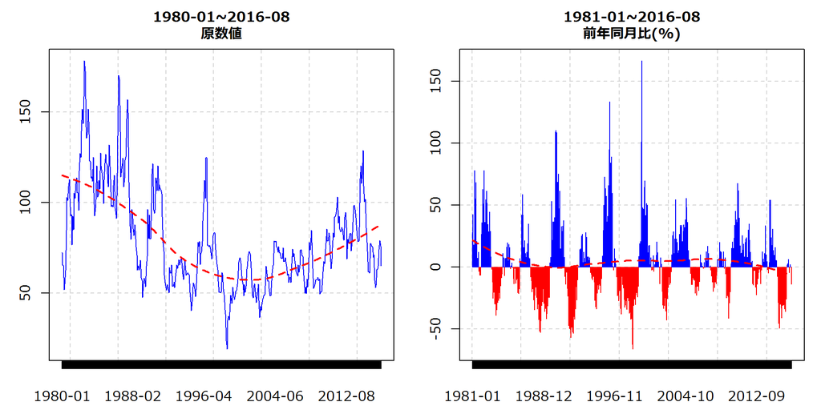

### Poultry (chicken), Whole bird spot price, Ready-to-cook, whole, iced, Georgia docks, US cents per pound . Type: USD

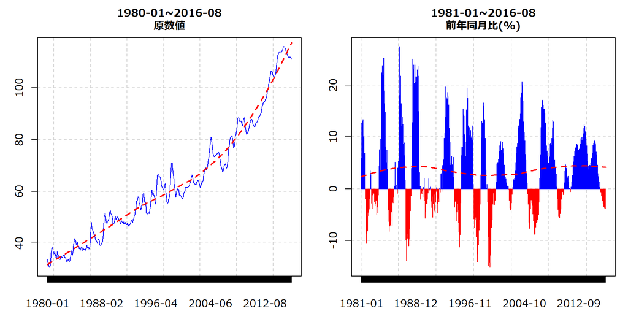

### Rice, 5 percent broken milled white rice, Thailand nominal price quote, US$ per metric ton . Type: USD

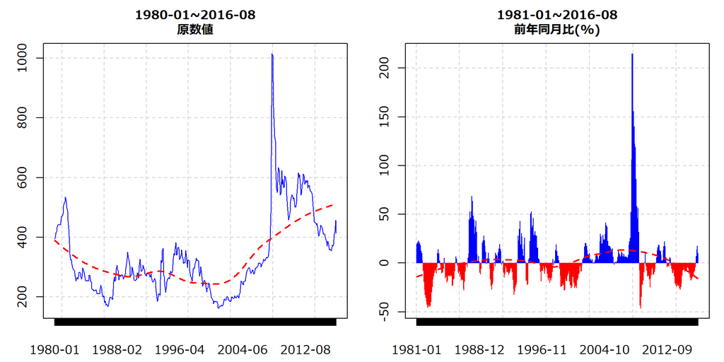

### Rubber, Singapore Commodity Exchange, No. 3 Rubber Smoked Sheets, 1st contract, US cents per pound . Type: USD

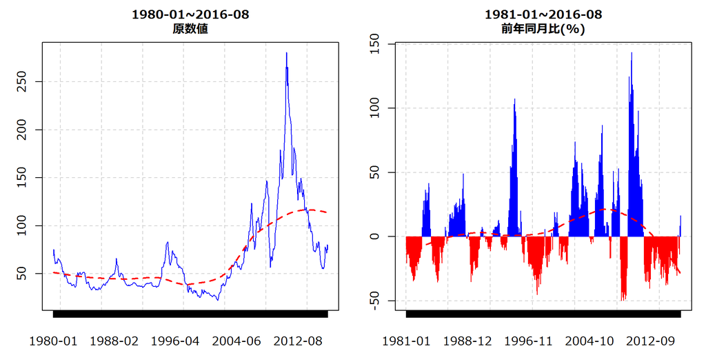

### Fish (salmon), Farm Bred Norwegian Salmon, export price, US$ per kilogram . Type: USD

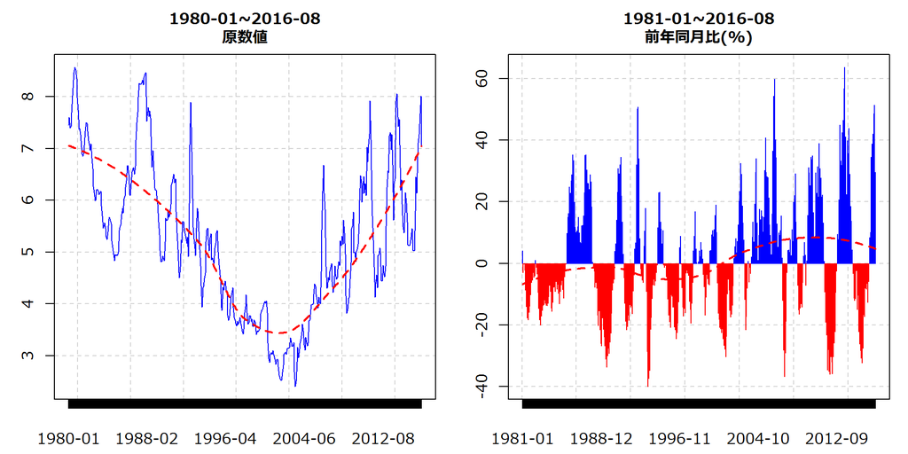

### Hard Sawnwood, Dark Red Meranti, select and better quality, C&F U.K port, US$ per cubic meter . Type: USD

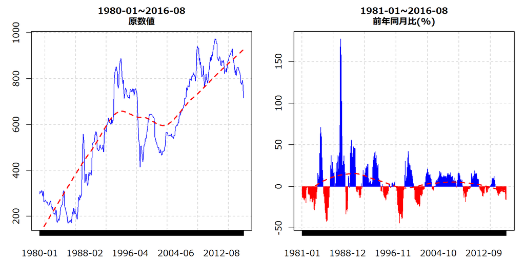

### Soft Sawnwood, average export price of Douglas Fir, U.S. Price, US$ per cubic meter . Type: USD

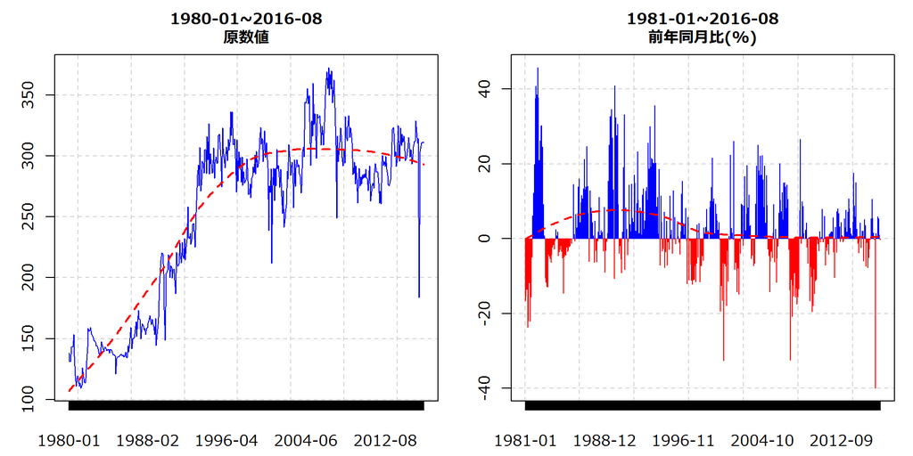

### Shrimp, No.1 shell-on headless, 26-30 count per pound, Mexican origin, New York port, US$ per kilogram . Type: USD

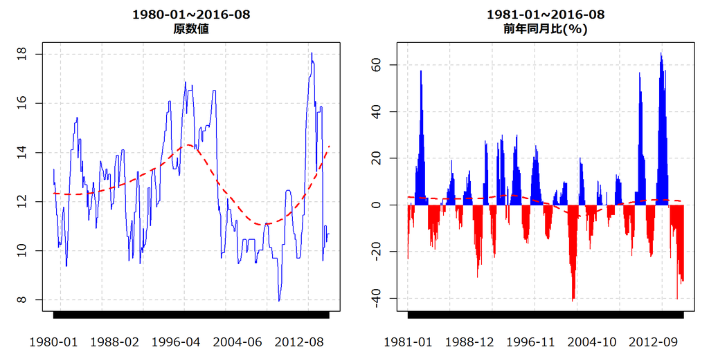

### Soybean Meal, Chicago Soybean Meal Futures (first contract forward) Minimum 48 percent protein, US$ per metric ton . Type: USD

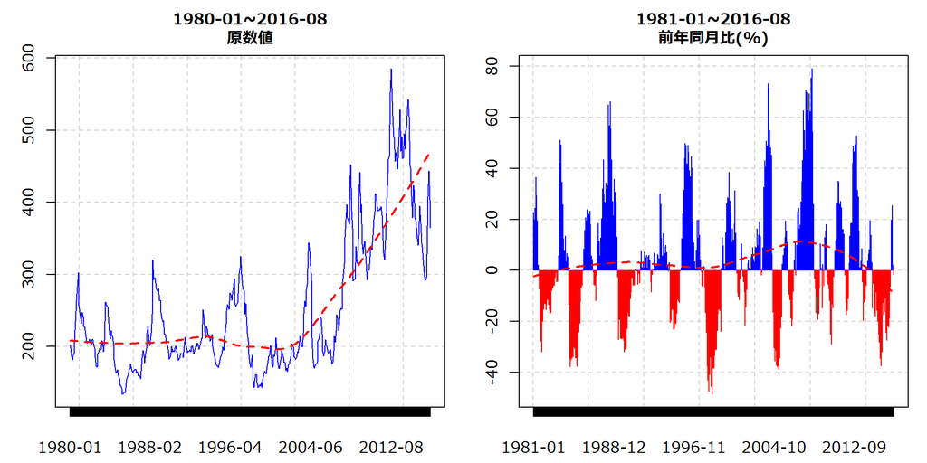

### Soybean Oil, Chicago Soybean Oil Futures (first contract forward) exchange approved grades, US$ per metric ton . Type: USD

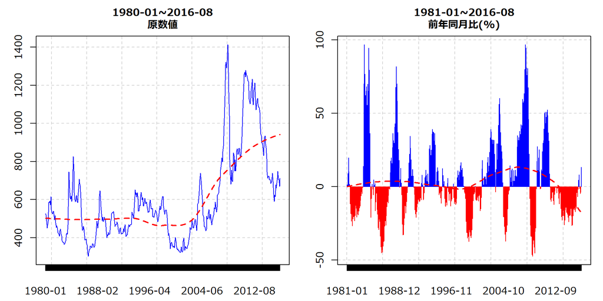

### Soybeans, U.S. soybeans, Chicago Soybean futures contract (first contract forward) No. 2 yellow and par, US$ per metric ton . Type: USD

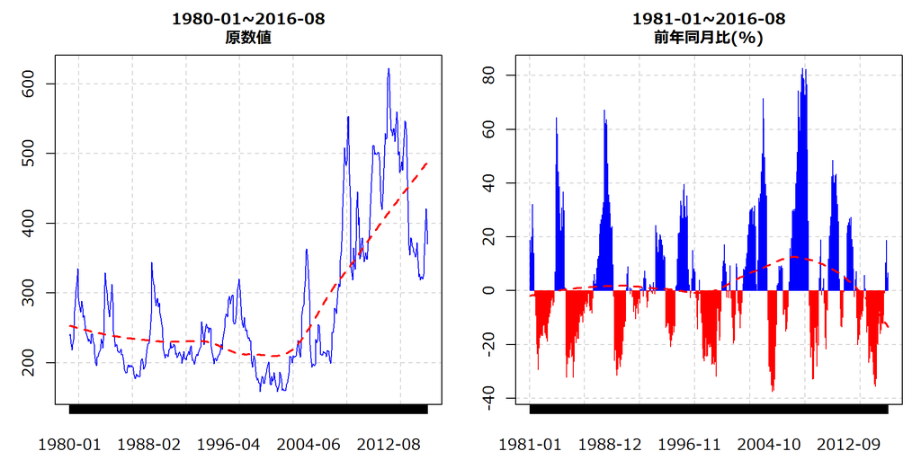

### Sugar, European import price, CIF Europe, US cents per pound . Type: USD

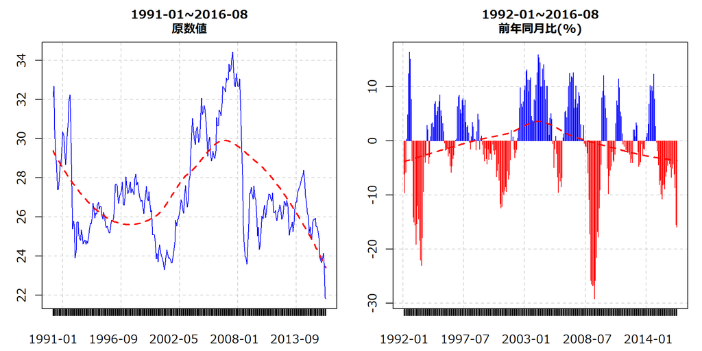

### Sugar, Free Market, Coffee Sugar and Cocoa Exchange (CSCE) contract no.11 nearest future position, US cents per pound . Type: USD

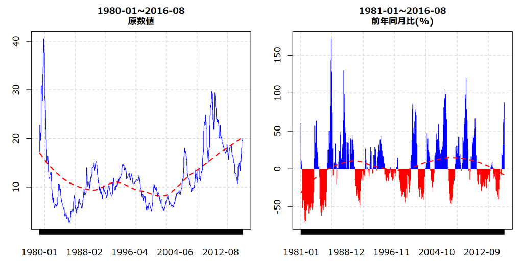

### Sugar, U.S. import price, contract no.14 nearest futures position, US cents per pound (Footnote: No. 14 revised to No. 16) . Type: USD

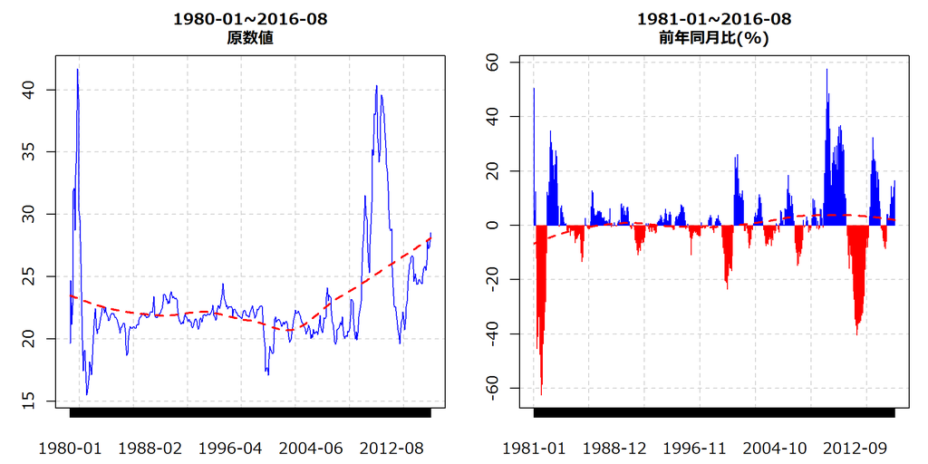

### Sunflower oil, Sunflower Oil, US export price from Gulf of Mexico, US$ per metric ton . Type: USD

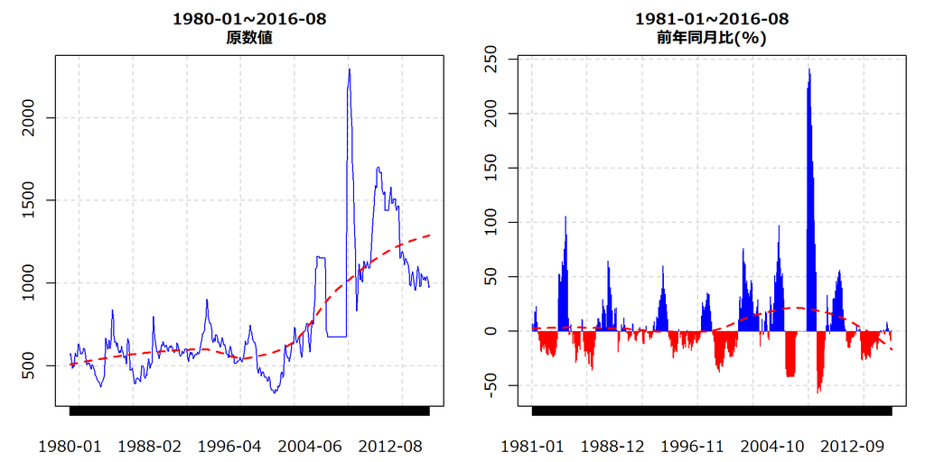

### Tea, Mombasa, Kenya, Auction Price, US cents per kilogram, From July 1998,Kenya auctions, Best Pekoe Fannings. Prior, London auctions, c.i.f. U.K. warehouses . Type: USD

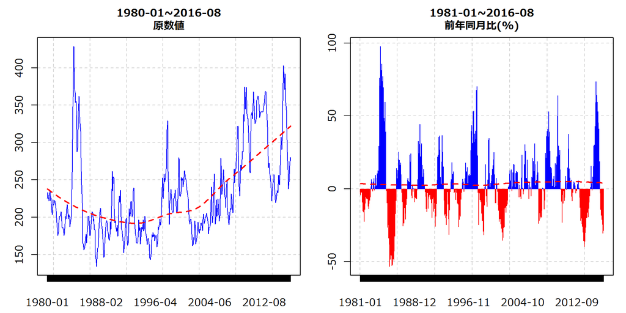

### Tin, standard grade, LME spot price, US$ per metric ton . Type: USD

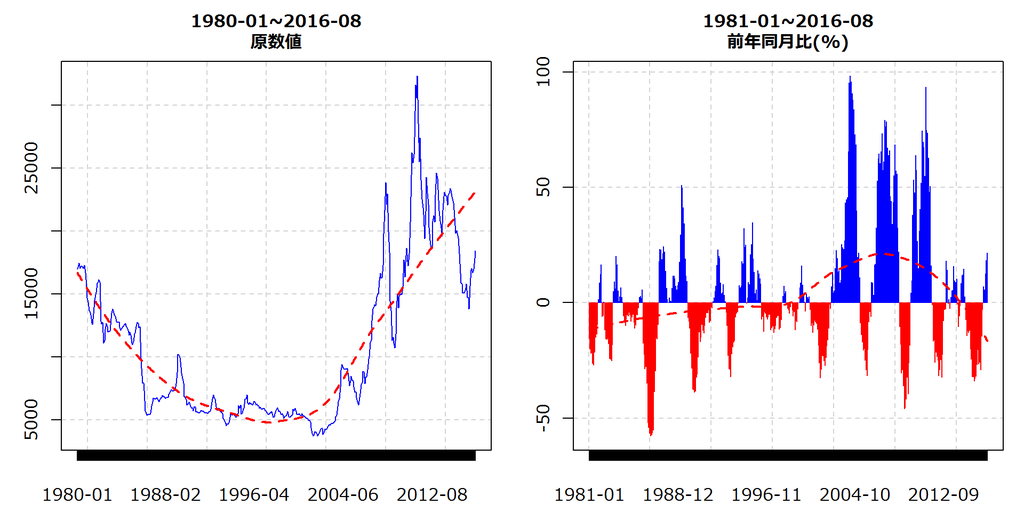

### Uranium, NUEXCO, Restricted Price, Nuexco exchange spot, US$ per pound . Type: USD

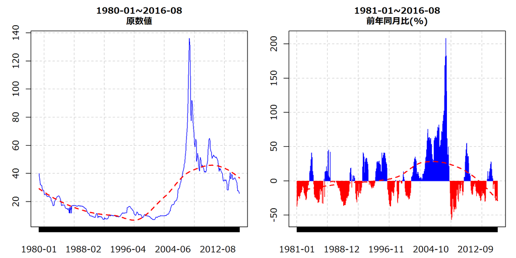

### Wheat, No.1 Hard Red Winter, ordinary protein, Kansas City, US$ per metric ton . Type: USD

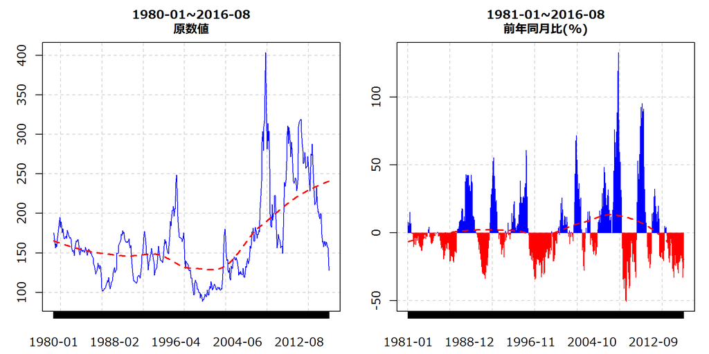

### Wool, coarse, 23 micron, Australian Wool Exchange spot quote, US cents per kilogram . Type: USD

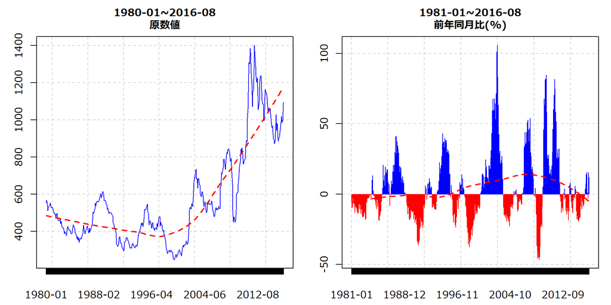

### Wool, fine, 19 micron, Australian Wool Exchange spot quote, US cents per kilogram . Type: USD

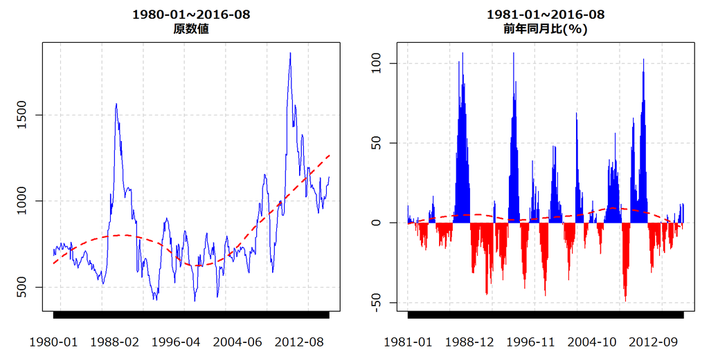

### Zinc, high grade 98% pure, US$ per metric ton . Type: USD

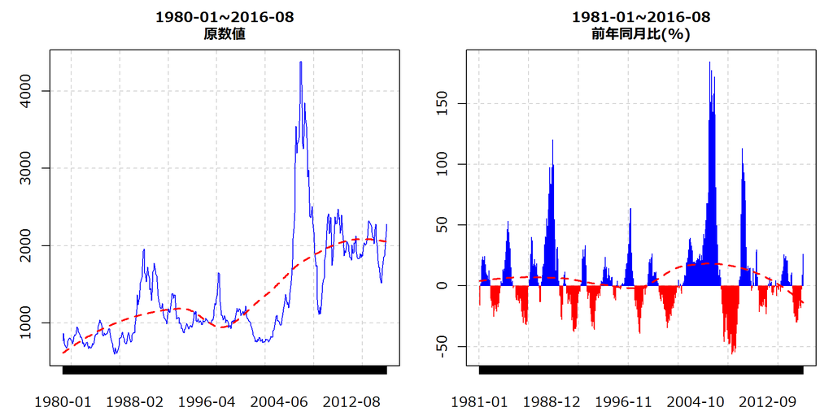